# Otimização_Covid_GUROBI

### COVID-19: Otimização da Capacidade de Unidade de Saúde utilizando a biblioteca Gurobi

#### Estudo foi baseado Copyright © 2020 Gurobi Optimization, LLC

#### Por: RODRIGO SOUZA

Meu Linkedin: https://www.linkedin.com/in/ssrodrigo

#### Introdução

O que irei encontrar por aqui?

Este problema de otimização da capacidade de capacidade do COVID-19 mostra como determinar a localização e a capacidade ideais das unidades de saúde para:

Satisfazer a demanda dos pacientes COVID-19 para tratamento, Minimizar o custo de abertura de instalações temporárias para prestadores de cuidados de saúde, e Prever a alocação de pacientes COVID-19 de um condado específico para uma unidade de saúde específica.

**Descrição do problema**

Hospitais em vários condados em todo os EUA estão atingindo a capacidade total devido a um aumento de pacientes COVID-19. Muitos hospitais estão considerando criar instalações temporárias para aumentar sua capacidade de lidar com pacientes COVID-19.

Neste exemplo, focamos em nove condados nos EUA. Cada município possui instalações existentes para tratar pacientes COVID-19, e também tem a opção de construir instalações temporárias para aumentar a capacidade geral de lidar com pacientes COVID-19.

A tabela a seguir define as coordenadas do centroide e a demanda prevista (ou seja, o número projetado de pacientes COVID-19) de cada município. Para estimar essa demanda, consideramos a população de nove condados fictícios na Califórnia, o número atual de casos COVID-19 por dia na Califórnia, a porcentagem média de casos COVID-19 que necessitam de internação, e o número médio de dias que um paciente COVID-19 permanece no hospital.

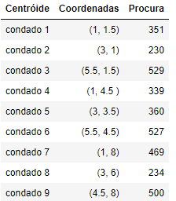

A tabela a seguir define as coordenadas e a capacidade das instalações existentes. A capacidade das instalações existentes é calculada em 80% da demanda prevista do município em que estão localizadas as instalações existentes. A exceção a isso é o condado 9, onde assumimos que temos um excesso da capacidade existente.

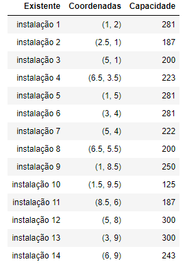

A tabela a seguir define as coordenadas e a capacidade de novas instalações temporárias. O custo da construção de uma instalação temporária com capacidade de tratar cem pacientes COVID-19 é $500,000 dólares .

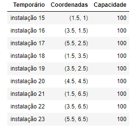

As coordenadas das três mesas estão em dezenas de milhas. Assumimos que cada aumento de 10 milhas na distância para uma instalação COVID-19 resulta em um $5 aumento nos custos de condução para cada paciente COVID-19.**

Neste exemplo, o objetivo é identificar quais instalações temporárias construir para poder acomodar a demanda de tratamento por pacientes COVID-19, minimizando o custo total dos pacientes COVID-19 dirigindo para uma instalação COVID-19 existente ou temporária e o custo total da construção de instalações temporárias.

Este exemplo mostra como um modelo de programação de integer misto (MIP) de localização de instalações pode ajudar os provedores de saúde a tomar decisões sobre:

Como utilizar melhor sua capacidade, Se construir instalações temporárias para pacientes COVID-19, e Como os pacientes COVID-19 de um município devem ser alocados em várias unidades de saúde, a fim de garantir que as instalações tenham capacidade de fornecer tratamento para os pacientes.

** Este Caderno Jupyter é baseado no artigo escrito por Katherine Klise e Michael Bynum [1].

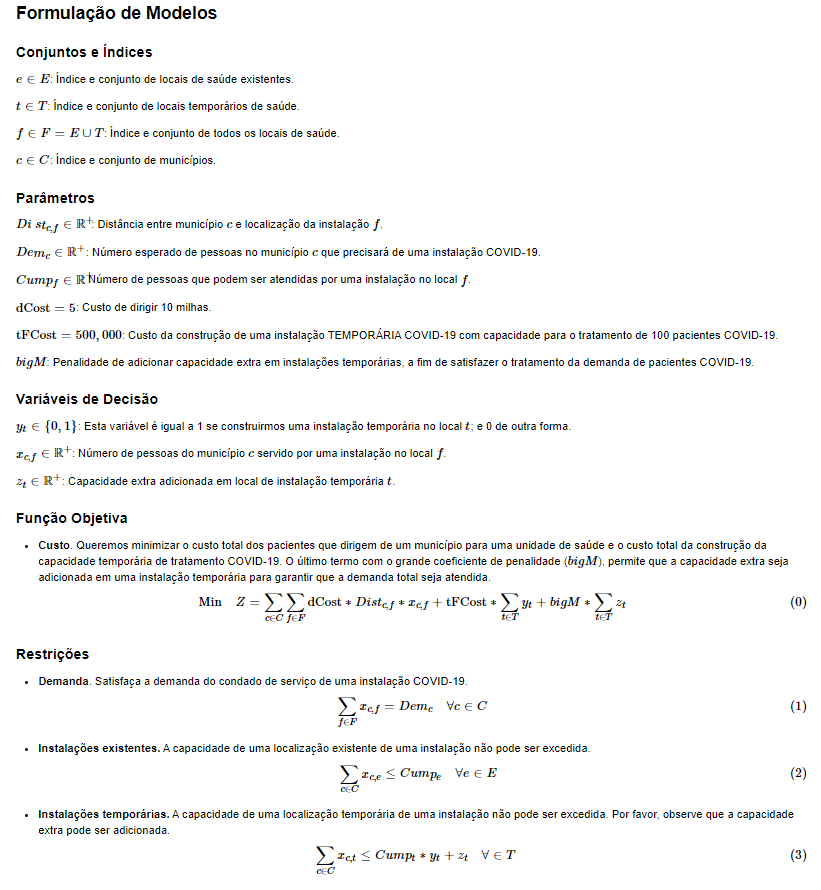

Implementação python Agora importamos o Módulo Gurobi Python e outras bibliotecas Python.

```python
pip install gurobipy
```

```python
from itertools import product
from math import sqrt

import gurobipy as gp
from gurobipy import GRB

# tested with Gurobi v9.1.0 and Python 3.7.0
```

**Funções de ajudante**

**compute_distance** calcula distância entre um centroide condado e a localização de uma instalação

**solve_covid19_facility** constrói, resolve e imprime resultados do modelo de otimização da capacidade de capacidade de saúde COVID-19

```python
def compute_distance(loc1, loc2):

    # This function determines the Euclidean distance between a facility and a county centroid.

    dx = loc1[0] - loc2[0]
    dy = loc1[1] - loc2[1]
    return sqrt(dx*dx + dy*dy)
```

```python
def solve_covid19_facility(c_coordinates, demand):

    #####################################################
    #                    Data
    #####################################################

    # Indices for the counties
    counties = [*range(1,10)]

    # Indices for the facilities
    facilities = [*range(1,24)]

    # Cria dicionário para capturar as coordenadas dos facilities e capacidades para tratamento de pacientes covid

    existing, e_coordinates, e_capacity  = gp.multidict({
        1: [(1, 2), 281],
        2: [(2.5, 1), 187],
        3: [(5, 1), 200],
        4: [(6.5, 3.5), 223],
        5: [(1, 5), 281],
        6: [(3, 4), 281],
        7: [(5, 4), 222],
        8: [(6.5, 5.5), 200],
        9: [(1, 8.5), 250],
        10: [(1.5, 9.5), 125],
        11: [(8.5, 6), 187],
        12: [(5, 8), 300],
        13: [(3, 9), 300],
        14: [(6, 9), 243]
    })

    # Crie um dicionário para capturar as coordenadas de uma instalação temporária e capacidade de tratar pacientes COVID-19

    temporary, t_coordinates, t_capacity  = gp.multidict({
        15: [(1.5, 1), 100],
        16: [(3.5, 1.5), 100],
        17: [(5.5, 2.5), 100],
        18: [(1.5, 3.5), 100],
        19: [(3.5, 2.5), 100],
        20: [(4.5, 4.5), 100],
        21: [(1.5, 6.5), 100],
        22: [(3.5, 6.5), 100],
        23: [(5.5, 6.5), 100]
    })

    # Cost of driving 10 miles
    dcost = 5

    # Cost of building a temporary facility with capacity of 100 COVID-19
    tfcost = 500000

    # Compute key parameters of MIP model formulation
    f_coordinates = {}
    for e in existing:
        f_coordinates[e] = e_coordinates[e]

    for t in temporary:
        f_coordinates[t] = t_coordinates[t]

    # Cartesian product of counties and facilities
    cf = []

    for c in counties:
        for f in facilities:
            tp = c,f
            cf.append(tp)

    # Compute distances between counties centroids and facility locations
    distance = {(c,f): compute_distance(c_coordinates[c], f_coordinates[f]) for c, f in cf}

    #####################################################
    #                    MIP Model Formulation
    #####################################################

    m = gp.Model('covid19_temporary_facility_location')

    # Build temporary facility
    y = m.addVars(temporary, vtype=GRB.BINARY, name='temporary')

    # Assign COVID-19 patients of county to facility
    x = m.addVars(cf, vtype=GRB.CONTINUOUS, name='Assign')

    # Add capacity to temporary facilities
    z = m.addVars(temporary, vtype=GRB.CONTINUOUS, name='addCap' )

    # Objective function: Minimize total distance to drive to a COVID-19 facility

    # Big penalty for adding capacity at a temporary facility
    bigM = 1e9

    m.setObjective(gp.quicksum(dcost*distance[c,f]*x[c,f] for c,f in cf)
                   + tfcost*y.sum()
                   + bigM*z.sum(), GRB.MINIMIZE)

    # Counties demand constraints
    demandConstrs = m.addConstrs((gp.quicksum(x[c,f] for f in facilities) == demand[c] for c in counties),
                                 name='demandConstrs')

    # Existing facilities capacity constraints
    existingCapConstrs = m.addConstrs((gp.quicksum(x[c,e]  for c in counties) <= e_capacity[e] for e in existing ),
                                      name='existingCapConstrs')

    # temporary facilities capacity constraints
    temporaryCapConstrs = m.addConstrs((gp.quicksum(x[c,t]  for c in counties) -z[t]
                                        <= t_capacity[t]*y[t] for t in temporary ),
                                       name='temporaryCapConstrs')
    # Run optimization engine
    m.optimize()

    #####################################################
    #                    Output Reports
    #####################################################

    # Total cost of building temporary facility locations
    temporary_facility_cost = 0

    print(f"\n\n_____________Custos ótimos______________________")
    for t in temporary:
        if (y[t].x > 0.5):
            temporary_facility_cost += tfcost*round(y[t].x)

    patient_allocation_cost = 0
    for c,f in cf:
        if x[c,f].x > 1e-6:
            patient_allocation_cost += dcost*round(distance[c,f]*x[c,f].x)

    print(f"O custo total da construção de instalações temporárias de healhtcare COVID-19 é ${temporary_facility_cost:,}")
    print(f"O custo total de alocar pacientes COVID-19 para instalações de cuidados de cura é is ${patient_allocation_cost:,}")

    # Build temporary facility at location

    print(f"\n_____________Plano para instalações temporárias______________________")
    for t in temporary:
        if (y[t].x > 0.5):
            print(f"Construir uma instalação temporária no local {t}")

    # Extra capacity at temporary facilities
    print(f"\n_____________Plano para aumentar a capacidade em instalações temporárias______________________")
    for t in temporary:
        if (z[t].x > 1e-6):
            print(f"Aumentar a capacidade de instalação temporária no local {t} por {round(z[t].x)} camas")

    # Demand satisfied at each facility
    f_demand = {}

    print(f"\n_____________Alocação de pacientes do condado para a unidade de saúde COVID-19______________________")
    for f in facilities:
        temp = 0
        for c in counties:
            allocation = round(x[c,f].x)
            if allocation > 0:
                print(f"{allocation} Pacientes COVID-19 do condado {c} são tratados em instalações {f} ")
            temp += allocation
        f_demand[f] = temp
        print(f"{temp} é o número total de pacientes COVID-19 que são tratados na instalação{f}. ")
        print(f"\n________________________________________________________________________________")

    # Test total demand = total demand satisfied by facilities
    total_demand = 0

    for c in counties:
        total_demand += demand[c]

    demand_satisfied = 0
    for f in facilities:
        demand_satisfied += f_demand[f]

    print(f"\n_____________Test demand = supply______________________")
    print(f"A demanda total é: {total_demand:,} patients")
    print(f"Demanda total satisfeita é: {demand_satisfied:,} camas")
```

**Cenário base** Nesse cenário, consideramos os dados descritos para o caso do problema de Otimização da Capacidade de Capacidade de Saúde COVID-19. A demanda prevista está definida na primeira tabela da descrição do problema.

```python
# Create a dictionary to capture the coordinates of a county and the demand of COVID-19 treatment

counties, coordinates, forecast  = gp.multidict({
    1: [(1, 1.5), 351],
    2: [(3, 1), 230],
    3: [(5.5, 1.5), 529],
    4: [(1, 4.5 ), 339],
    5: [(3, 3.5), 360],
    6: [(5.5, 4.5), 527],
    7: [(1, 8), 469],
    8: [(3, 6), 234],
    9: [(4.5, 8), 500]
})


# find the optimal solution of the base scenario
solve_covid19_facility(coordinates, forecast)
```

```
Set parameter Username

--------------------------------------------
Warning: your license will expire in 8 days
--------------------------------------------

Academic license - for non-commercial use only - expires 2021-12-03
Gurobi Optimizer version 9.5.0 build v9.5.0rc5 (win64)
Thread count: 2 physical cores, 4 logical processors, using up to 4 threads
Optimize a model with 32 rows, 225 columns and 432 nonzeros
Model fingerprint: 0xbb38e066
Variable types: 216 continuous, 9 integer (9 binary)
Coefficient statistics:
  Matrix range     [1e+00, 1e+02]
  Objective range  [3e+00, 1e+09]
  Bounds range     [1e+00, 1e+00]
  RHS range        [1e+02, 5e+02]
Presolve time: 0.00s
Presolved: 32 rows, 225 columns, 432 nonzeros
Variable types: 216 continuous, 9 integer (9 binary)
Found heuristic solution: objective 4016967.0542

Root relaxation: objective 1.317174e+06, 59 iterations, 0.00 seconds (0.00 work units)

    Nodes    |    Current Node    |     Objective Bounds      |     Work
 Expl Unexpl |  Obj  Depth IntInf | Incumbent    BestBd   Gap | It/Node Time

     0     0 1317174.01    0    3 4016967.05 1317174.01  67.2%     -    0s
H    0     0                    2020218.8911 1317174.01  34.8%     -    0s
     0     0 1317555.14    0    4 2020218.89 1317555.14  34.8%     -    0s
H    0     0                    1521653.4243 1317555.14  13.4%     -    0s
     0     0 1317573.06    0    5 1521653.42 1317573.06  13.4%     -    0s
     0     0 1317619.99    0    3 1521653.42 1317619.99  13.4%     -    0s
     0     0 1317619.99    0    3 1521653.42 1317619.99  13.4%     -    0s
     0     2 1317619.99    0    3 1521653.42 1317619.99  13.4%     -    0s

Cutting planes:
  Gomory: 4
  MIR: 6
  Relax-and-lift: 2
```

[output cut: 104 more lines]

[output not shown]

**Análise para Cenário Base** O custo total ideal de construção de unidades de saúde temporárias COVID-19 é $1,500,000 e três unidades de saúde temporárias COVID-19 são construídas. O custo total de alocação de pacientes COVID-19 para unidades de saúde é $21,645 dólares , e nenhuma capacidade extra precisa ser adicionada para acomodar a demanda de tratamento dos pacientes COVID-19.

O modelo MIP também determina o número esperado de pacientes COVID-19 de um município alocados em uma unidade de saúde. Por exemplo, 6 pacientes COVID-19 do condado 3, 50 pacientes COVID-19 do condado 5 e 166 pacientes COVID-19 do condado 6 devem ser tratados na unidade 7. O número total de pacientes COVID-19 que devem ser tratados na unidade 7 é de 222.

**Cenário 1** Suponha que os Centros de Controle e Prevenção de Doenças (CDC) anunciaram que o número de internações aumentará em 20%. Esse percentual inclui 5% da capacidade de tampão para responder pela variabilidade da demanda esperada.

```python
# Increase in demand by 20%.

for c in counties:
    forecast[c] = round(1.2*forecast[c])

# find the optimal for scenario 1
solve_covid19_facility(coordinates, forecast)
```

[output not shown]

[output cut: 99 more lines]

[output not shown]

**Análise para o Cenário 1**

O custo total ideal de construção de unidades de saúde COVID-19 temporárias é $4,500,000 , e são construídas nove unidades de saúde temporárias COVID-19. O custo total de alocação de pacientes COVID-19 para unidades de saúde é $25,520 dólares , e 40 e 27 leitos precisam ser adicionados nas unidades de saúde temporárias 15 e 17, respectivamente.

Observe que, neste cenário, o sistema está sobrecarregado e todas as unidades de saúde COVID-19 estão operando em plena capacidade. Além disso, é preciso adicionar capacidade extra em algumas unidades de saúde temporárias.

**Conclusão**

Neste exemplo, abordamos o problema de otimização da capacidade de saúde COVID-19. Determinamos a localização e a capacidade ideais das unidades de saúde para:

- Satisfazer a demanda dos pacientes COVID-19 para tratamento,
- Minimizar o custo de abertura de instalações temporárias para prestadores de cuidados de saúde, e
- Prever a alocação de pacientes COVID-19 de um condado específico para uma unidade de saúde específica. Exploramos dois cenários. No cenário base, temos capacidade suficiente e precisamos construir três unidades de saúde temporárias. Considerando que no cenário alternativo (1) com aumento de 20% no número de pacientes COVID-19 que necessitam de internação, precisamos construir nove unidades de saúde temporárias e adicionar capacidade extra em dois deles.

Nosso modelo de Otimização de Localização de Instalações de Saúde COVID-19 pode ser usado por funcionários da saúde pública e prestadores de cuidados de saúde para ajudar a tomar decisões estratégicas sobre quando e onde aumentar a capacidade das unidades de saúde durante a pandemia COVID-19. Além disso, este modelo estratégico pode alimentar informações para um modelo de despacho de balanceamento de carga COVID-19 capaz de atribuir (em tempo real) pacientes COVID-19 que necessitam de internação nas unidades de saúde "certas".

Além disso, nosso modelo pode se alimentar de um modelo tático que determina como a capacidade deve ser aumentada para acomodar qualquer aumento na demanda. Por exemplo, o número de pessoal médico a ser contratado, treinado e re-qualificado, o rodízio de pessoal médico, e a quantidade de equipamentos (por exemplo, ventiladores, medicamentos, leitos, etc.) necessários.

Referências [1] Katherine Klise e Michael Bynum. Modelo de otimização de localização de instalações para recursos COVID-19. Abril de 2020. Capacidade de modelagem e análise de pandemia de laboratório doE. SAND2020-4693R.

Copyright © 2020 Gurobi Optimization, LLC